# Mass shooting tracker 2013-2015

Gabi Huiber

October 4, 2015

Shooting data from [here](http://shootingtracker.com/wiki/Main_Page) covers years 2013-2015 (as of this writing). If you pair it with 2014 population data from [this .csv file](http://www.census.gov/popest/data/state/totals/2014/tables/NST-EST2014-01.csv), you can get an idea of the daily risk of dying or being wounded in a mass shooting across the US, by state, as shown below:

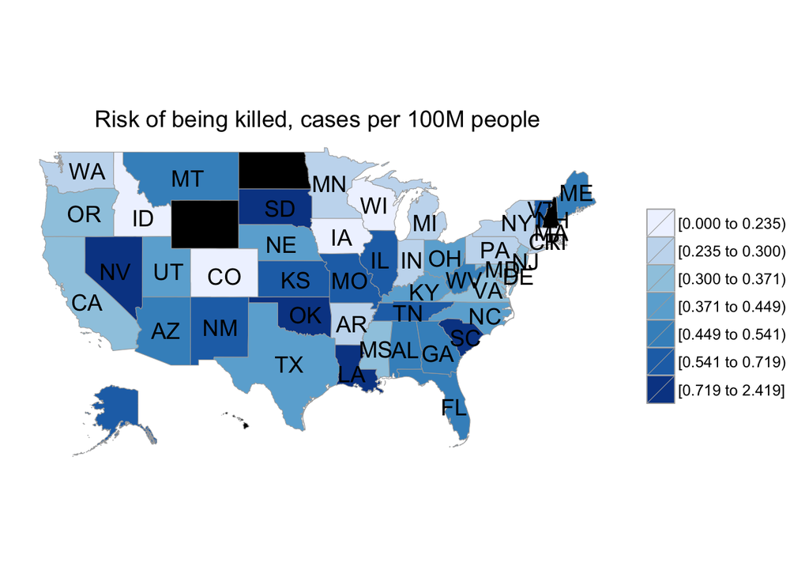

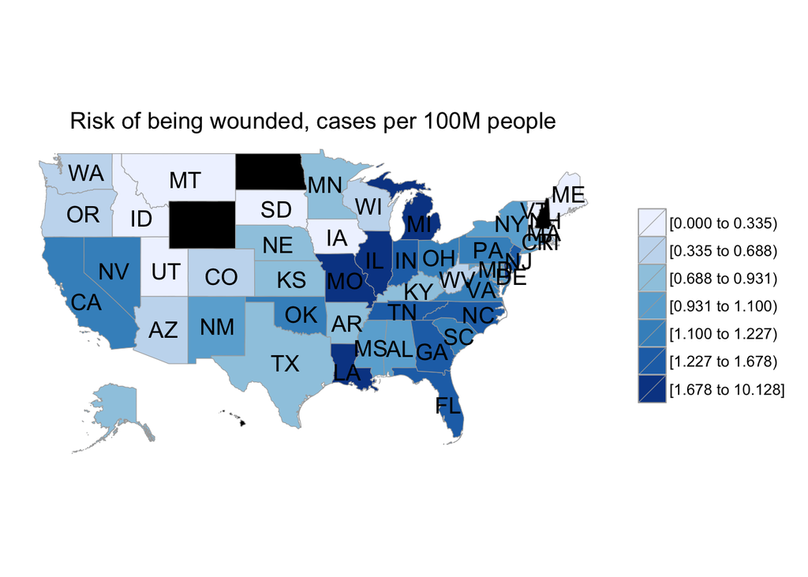

The impetus for this came from [this WonkBlog post](http://www.washingtonpost.com/news/wonkblog/wp/2015/10/01/2015-274-days-294-mass-shootings-hundreds-dead/). A headline that points out that so far this year there have been more mass shootings than days will get anybody’s attention. After one agrees that things are indeed bad, a fair question might be whether they’re getting worse.

The evidence of that is mixed. Translated to daily risk (as approximated by incidence of the dead and wounded per 100M person-days), this year is worse than 2014, about as bad as 2013 for the risk of dying, and worse for the risk of getting wounded:

| year | days | population | dead | wounded | dead_incidence_100M | wounded_incidence_100M |
| --- | --- | --- | --- | --- | --- | --- |
| 2013 | 365 | 318335444 | 502 | 1266 | 0.43 | 1.09 |
| 2014 | 365 | 318335444 | 383 | 1251 | 0.33 | 1.08 |
| 2015 | 274 | 318335444 | 375 | 1089 | 0.43 | 1.25 |

The numbers in the table above take the 2014 US population as baseline. If this population is higher in 2015 than it was in 2014, then the risks estimated on the bottom row of this table will be slightly lower, but this should be close enough for a rough idea.